# Machine Learning: Mathematical Theory and Applications

Computer lab 2

Nicholas Millar and Edward Mckenzie

Published

September 26, 2023

## 1. Bagging and boosting for bike rental data (regression)

```r
rm(list=ls()) # Remove variables
cat("\014") # Clean workspace
```

```r
suppressMessages(library(dplyr))
suppressMessages(library(splines))
suppressMessages(library(randomForest))
suppressMessages(library(xgboost))

bike_data = read.csv("bike_rental_hourly.csv")


head(bike_data)
```

```
  instant     dteday season yr mnth hr holiday weekday workingday weathersit
1       1 2011-01-01      1  0    1  0       0       6          0          1
2       2 2011-01-01      1  0    1  1       0       6          0          1
3       3 2011-01-01      1  0    1  2       0       6          0          1
4       4 2011-01-01      1  0    1  3       0       6          0          1
5       5 2011-01-01      1  0    1  4       0       6          0          1
6       6 2011-01-01      1  0    1  5       0       6          0          2
  temp  atemp  hum windspeed casual registered cnt
1 0.24 0.2879 0.81    0.0000      3         13  16
2 0.22 0.2727 0.80    0.0000      8         32  40
3 0.22 0.2727 0.80    0.0000      5         27  32
4 0.24 0.2879 0.75    0.0000      3         10  13
5 0.24 0.2879 0.75    0.0000      0          1   1
6 0.24 0.2576 0.75    0.0896      0          1   1
```

```r
bike_data$log_cnt <- log(bike_data$cnt)
bike_data$hour <- bike_data$hr/23 # transform [0, 23] to [0, 1]. 0 is midnight, 1 is 11 PM

# One hot for weathersit
one_hot_encode_weathersit <- model.matrix(~ as.factor(weathersit) - 1,data = bike_data)
one_hot_encode_weathersit  <- one_hot_encode_weathersit[, -1] # Remove reference category
colnames(one_hot_encode_weathersit) <- c('cloudy', 'light rain', 'heavy rain')
bike_data <- cbind(bike_data, one_hot_encode_weathersit)

# One hot for weekday
one_hot_encode_weekday <- model.matrix(~ as.factor(weekday) - 1,data = bike_data)
one_hot_encode_weekday  <- one_hot_encode_weekday[, -1] # Remove reference category
colnames(one_hot_encode_weekday) <- c('Mon', 'Tue', 'Wed', 'Thu', 'Fri', 'Sat')
bike_data <- cbind(bike_data, one_hot_encode_weekday)

# One hot for weekday
one_hot_encode_season <- model.matrix(~ as.factor(season) - 1,data = bike_data)
one_hot_encode_season  <- one_hot_encode_season[, -1] # Remove reference category
colnames(one_hot_encode_season) <- c('Spring', 'Summer', 'Fall')
bike_data <- cbind(bike_data, one_hot_encode_season)

# Create lags
bike_data_new <- mutate(bike_data, lag1 = lag(log_cnt, 1), lag2 = lag(log_cnt, 2),
                        lag3 = lag(log_cnt, 3), lag4 = lag(log_cnt, 4), lag24 = lag(log_cnt, 24))

bike_data_new <- bike_data_new[-c(1:24),] # Lost 24 obs because of lagging

# Create training and test data
bike_all_data_train <- bike_data_new[bike_data_new$dteday >= as.Date("2011-01-01") & bike_data_new$dteday <=  as.Date("2012-05-31"), ]
bike_all_data_test <- bike_data_new[bike_data_new$dteday >= as.Date("2012-06-01") & bike_data_new$dteday <=  as.Date("2012-12-31"), ]
X_train <- cbind(1, bike_all_data_train[, c("lag1", "lag2",  "lag3", "lag4", "lag24")])
spline_basis <- ns(bike_all_data_train$hour, df = 10, intercept = FALSE)
X_train <- cbind(X_train, spline_basis)
colnames(X_train)[1] <- "intercept"
knots <- attr(spline_basis, "knots")
variables_to_keep_in_X <- c("yr", "holiday", "workingday", "temp", "atemp", "hum", "windspeed")
variables_to_keep_in_X <- c(variables_to_keep_in_X, colnames(one_hot_encode_weathersit), colnames(one_hot_encode_weekday), colnames(one_hot_encode_season))
X_train <- cbind(X_train, bike_all_data_train[, variables_to_keep_in_X])
head(X_train)
```

```
   intercept     lag1     lag2     lag3     lag4    lag24          1          2
25         1 3.663562 3.332205 3.526361 3.583519 2.772589 0.00000000 0.00000000
26         1 2.833213 3.663562 3.332205 3.526361 3.688879 0.01785714 0.00000000
27         1 2.833213 2.833213 3.663562 3.332205 3.465736 0.14285714 0.00000000
28         1 2.197225 2.833213 2.833213 3.663562 2.564949 0.41785714 0.01428571
29         1 1.791759 2.197225 2.833213 2.833213 0.000000 0.62857143 0.11428571
30         1 1.098612 1.791759 2.197225 2.833213 0.000000 0.34285714 0.58095238
            3 4 5 6 7            8           9           10 yr holiday
25 0.00000000 0 0 0 0  0.000000000 0.000000000  0.000000000  0       0
26 0.00000000 0 0 0 0 -0.116963312 0.350889936 -0.233926624  0       0
27 0.00000000 0 0 0 0 -0.175067667 0.525203001 -0.350135334  0       0
28 0.00000000 0 0 0 0 -0.138695850 0.416087550 -0.277391700  0       0
29 0.00000000 0 0 0 0 -0.065197614 0.195592842 -0.130395228  0       0
30 0.06666667 0 0 0 0 -0.002414726 0.007244179 -0.004829453  0       0
   workingday temp  atemp  hum windspeed cloudy light rain heavy rain Mon Tue
25          0 0.46 0.4545 0.88    0.2985      1          0          0   0   0
26          0 0.44 0.4394 0.94    0.2537      1          0          0   0   0
27          0 0.42 0.4242 1.00    0.2836      1          0          0   0   0
28          0 0.46 0.4545 0.94    0.1940      1          0          0   0   0
29          0 0.46 0.4545 0.94    0.1940      1          0          0   0   0
30          0 0.42 0.4242 0.77    0.2985      0          1          0   0   0
   Wed Thu Fri Sat Spring Summer Fall
25   0   0   0   0      0      0    0
26   0   0   0   0      0      0    0
27   0   0   0   0      0      0    0
28   0   0   0   0      0      0    0
29   0   0   0   0      0      0    0
30   0   0   0   0      0      0    0
```

```r
# Training data
X_train <- as.matrix(X_train)
y_train <- bike_all_data_train$log_cnt
# Test data
y_test <- bike_all_data_test$log_cnt
X_test <- cbind(1, bike_all_data_test[, c("lag1", "lag2",  "lag3", "lag4", "lag24")])
spline_basis_test <- ns(bike_all_data_test$hour, df=10, knots=knots, intercept = FALSE)
X_test <- cbind(X_test, spline_basis_test)
colnames(X_test)[1] <- "intercept"
X_test <- cbind(X_test, bike_all_data_test[, variables_to_keep_in_X])
X_test <- as.matrix(X_test)
```

#### 💪 Problem 1.1

```r
#RMSE Function
RMSE = function(y_pred, y_actual){
    sqrt(mean((y_pred - y_actual)^2))
}

rf_50 = randomForest(X_train, y_train, ntree=50)
rf_100 = randomForest(X_train, y_train, ntree=100)
rf_150 = randomForest(X_train, y_train, ntree=150)
```

```r
yhat_train_50_forest = predict(rf_50, newdata=X_train)
yhat_train_100_forest = predict(rf_100, newdata=X_train)
yhat_train_150_forest = predict(rf_150, newdata=X_train)

yhat_test_50_forest = predict(rf_50, newdata=X_test)
yhat_test_100_forest = predict(rf_100, newdata=X_test)
yhat_test_150_forest = predict(rf_150, newdata=X_test)

rmse_y_hat_train_50 = RMSE(yhat_train_50_forest, y_train)
rmse_y_hat_train_100 = RMSE(yhat_train_100_forest, y_train)
rmse_y_hat_train_150 = RMSE(yhat_train_150_forest, y_train)

rmse_y_hat_test_50 = RMSE(yhat_test_50_forest, y_test)
rmse_y_hat_test_100 = RMSE(yhat_test_100_forest, y_test)
rmse_y_hat_test_150 = RMSE(yhat_test_150_forest, y_test)

#RMSE For Training
cat("\nRMSE for training 50 trees is ", rmse_y_hat_train_50)
```

```
RMSE for training 50 trees is  0.1435993
```

```r
cat("\nRMSE for training 100 trees is ", rmse_y_hat_train_100)
```

```
RMSE for training 100 trees is  0.1424814
```

```r
cat("\nRMSE for training 150 trees is ", rmse_y_hat_train_150)
```

```
RMSE for training 150 trees is  0.1401709
```

```r
#RMSE for Test
cat("\nRMSE for test 50 trees is ", rmse_y_hat_test_50)
```

```
RMSE for test 50 trees is  0.2931691
```

```r
cat("\nRMSE for test 100 trees is ", rmse_y_hat_test_100)
```

```
RMSE for test 100 trees is  0.2925991
```

```r
cat("\nRMSE for test 150 trees is ", rmse_y_hat_test_150)
```

```
RMSE for test 150 trees is  0.2932415
```

#### 💪 Problem 1.2

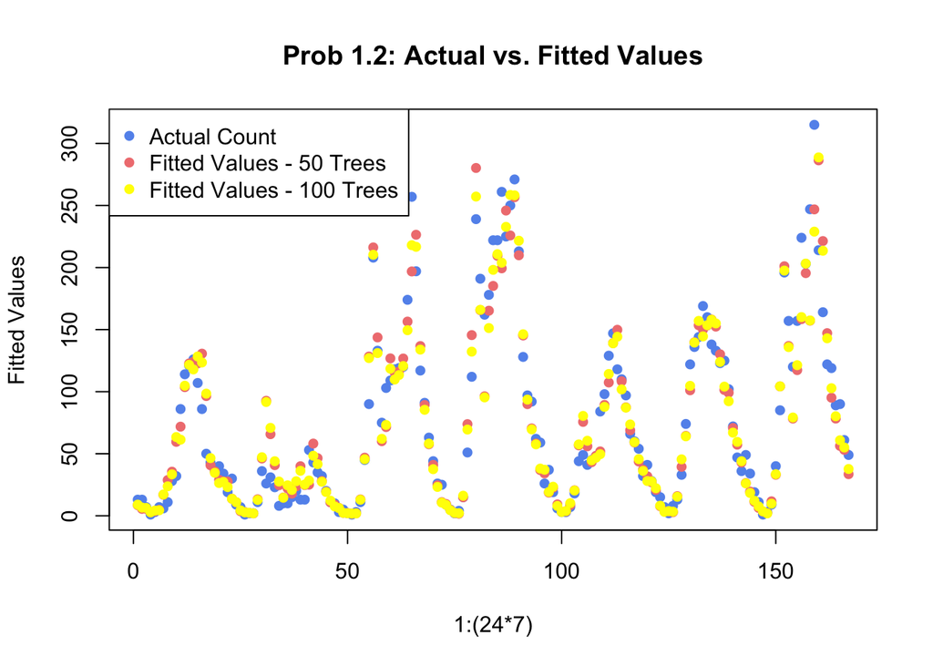

```r
#extract the last week of test data
last_week_test = bike_all_data_test[bike_all_data_test$dteday >= as.Date("2012-12-25") & bike_all_data_test$dteday <= as.Date("2012-12-31"), ]

#converting it to a data frame
yhat_test_50_forest = as.data.frame(yhat_test_50_forest)
yhat_test_100_forest = as.data.frame(yhat_test_100_forest)

#use row names from last_week_test to filter y_hat_test
fitted_values_last_week_50 = yhat_test_50_forest[row.names(last_week_test),]
fitted_values_last_week_100 = yhat_test_100_forest[row.names(last_week_test),]

n = 1:(24*7)[-c(168)] #creating numbers ranging from 1 to 167
n = n[-c(168)]

#Plot
plot(n, last_week_test$cnt,  xlab = "1:(24*7)",ylab = "Fitted Values",main = "Prob 1.2: Actual vs. Fitted Values",col = "cornflowerblue",pch = 16)
points(n, exp(fitted_values_last_week_50), col = "lightcoral", pch = 16)
points(n, exp(fitted_values_last_week_100), col = "yellow", pch = 16)
legend(x = "topleft", pch = c(16, 16), col = c("cornflowerblue", "lightcoral", "yellow"), legend=c("Actual Count", "Fitted Values - 50 Trees", "Fitted Values - 100 Trees"))
```

**The fit is quite similar between the 50 and 100 random forest models however as the RMSE for 100 is lower than 50 the 100 appears to be marginally a better model. For counts around the 40 mark, the actual observed values are lower then the predicted value.**

#### 💪 Problem 1.3

```r
#verbose = 0 stops the train-rmse from printing
fit_boost_10 = xgboost(data = as.matrix(X_train), label = y_train, nrounds = 10, verbose = 0)
fit_boost_25 = xgboost(data = as.matrix(X_train), label = y_train, nrounds = 25, verbose = 0)
fit_boost_50 = xgboost(data = as.matrix(X_train), label = y_train, nrounds = 50, verbose = 0)

yhat_train_10_boost = predict(fit_boost_10, newdata = as.matrix(X_train))
yhat_train_25_boost = predict(fit_boost_25, newdata = as.matrix(X_train))
yhat_train_50_boost = predict(fit_boost_50, newdata = as.matrix(X_train))

yhat_test_10_boost = predict(fit_boost_10, newdata = as.matrix(X_test))
yhat_test_25_boost = predict(fit_boost_25, newdata = as.matrix(X_test))
yhat_test_50_boost = predict(fit_boost_50, newdata = as.matrix(X_test))

rmse_y_hat_train_10 = RMSE(yhat_train_10_boost, y_train)
rmse_y_hat_train_25 = RMSE(yhat_train_25_boost, y_train)
rmse_y_hat_train_50 = RMSE(yhat_train_50_boost, y_train)

rmse_y_hat_test_10 = RMSE(yhat_test_10_boost, y_test)
rmse_y_hat_test_25 = RMSE(yhat_test_25_boost, y_test)
rmse_y_hat_test_50 = RMSE(yhat_test_50_boost, y_test)

#RMSE For Training
cat("\nRMSE for training 10 boost is ", rmse_y_hat_train_10)
```

```
RMSE for training 10 boost is  0.3234241
```

```r
cat("\nRMSE for training 25 boost is ", rmse_y_hat_train_25)
```

```
RMSE for training 25 boost is  0.2549957
```

```r
cat("\nRMSE for training 50 boost is ", rmse_y_hat_train_50)
```

```
RMSE for training 50 boost is  0.2157965
```

```r
#RMSE for Test
cat("\nRMSE for test 10 boost is ", rmse_y_hat_test_10)
```

```
RMSE for test 10 boost is  0.3670123
```

```r
cat("\nRMSE for test 25 boost is ", rmse_y_hat_test_25)
```

```
RMSE for test 25 boost is  0.3022917
```

```r
cat("\nRMSE for test 50 boost is ", rmse_y_hat_test_50)
```

```
RMSE for test 50 boost is  0.3003572
```

#### 💪 Problem 1.4

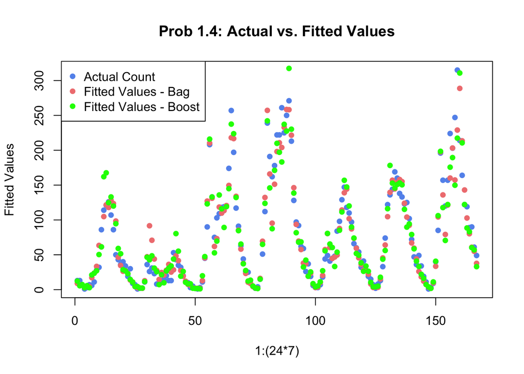

```r
#best bagging model in problem 1.2
yhat_test_100_forest = predict(rf_100, newdata=X_test)

#best boosting model from problem 1.3
yhat_test_50_boost = predict(fit_boost_50, as.matrix(X_test))

#converting it to a data frame
yhat_test_bag = as.data.frame(yhat_test_100_forest)

#use row names from last_week_test to filter y_hat_test
fitted_values_last_week_bag = yhat_test_bag[row.names(last_week_test),]
fitted_values_last_week_boost = tail(yhat_test_50_boost, nrow(last_week_test))


n = 1:(24*7)[-c(168)] #creating numbers ranging from 1 to 167
n = n[-c(168)]

#Plot
plot(n, last_week_test$cnt,  xlab = "1:(24*7)",ylab = "Fitted Values",main = "Prob 1.4: Actual vs. Fitted Values", col = "cornflowerblue", pch = 16)
points(n, exp(fitted_values_last_week_bag), col = "lightcoral", pch = 16)
points(n, exp(fitted_values_last_week_boost), col = "green", pch = 16)
legend(x = "topleft", pch = c(16, 16), col = c("cornflowerblue", "lightcoral", "green"), legend=c("Actual Count", "Fitted Values - Bag", "Fitted Values - Boost"))
```

**The bag and boosting model produce similar fitted values and both seem to be appropriate models for this problem. It does appear that boosting produces some extreme values such as around count 10 and count 70 when the bagging model does not.**

## 2. Bagging and boosting for spam email data (classification)

```r
rm(list=ls()) # Remove variables
cat("\014") # Clean workspace
```

```r
load(file = "spam_ham_emails.RData")
library(randomForest)
library(pROC)
library(caret)
library(xgboost)
Spam_ham_emails[, -1] <- scale(Spam_ham_emails[, -1])
Spam_ham_emails['spam'] <- as.factor(Spam_ham_emails['spam'] == 1) # Changing from 1->TRUE, 0->FALSE
levels(Spam_ham_emails$spam) <- c("not spam", "spam")
head(Spam_ham_emails)
```

```
      spam       over     remove   internet        free        hpl          X.
1 not spam -0.3502281 -0.2917622 -0.2625330 -0.30134485  4.2669752 -0.32987644
2     spam  1.6583607 -0.2917622  0.4106637  1.03071019 -0.2992074  0.38364598
3 not spam -0.3502281 -0.2917622 -0.2625330 -0.30134485  2.6659926 -0.32987644
4     spam  0.6358064 -0.2917622 -0.2625330 -0.30134485 -0.2992074 -0.28451505
5     spam  0.3436480  0.1936234 -0.2625330 -0.07126262 -0.2992074 -0.06996793
6     spam -0.3502281  0.9855684  0.9841276 -0.30134485 -0.2992074  0.17522878
        X..1   CapRunMax CapRunTotal        our         hp   george      X1999
1 -0.3083214 -0.17021174  0.02096274 -0.4642639  3.9791176 -0.22787  4.9900587
2  0.8751730 -0.08811470  0.01271665 -0.4642639 -0.3287789 -0.22787 -0.3234205
3 -0.3083214 -0.22665345 -0.40618481 -0.4642639 -0.3287789 -0.22787  2.7702052
4 -0.3083214 -0.09837683 -0.12416847 -0.4642639 -0.3287789 -0.22787 -0.3234205
5  0.9239769  0.40959862  0.75651413 -0.1817414 -0.3287789 -0.22787 -0.3234205
6  1.3672790 -0.17021174 -0.05655052  0.6658261 -0.3287789 -0.22787 -0.3234205
           re       edu
1  0.59185916 -0.197366
2 -0.03086294 -0.197366
3 -0.29774385 -0.197366
4 -0.29774385 -0.197366
5 -0.29774385 -0.197366
6 -0.29774385 -0.197366
```

```r
set.seed(1234)
suppressMessages(library(caret))
train_obs <- createDataPartition(y = Spam_ham_emails$spam, p = .75, list = FALSE)
train <- Spam_ham_emails[train_obs, ]
y_train <- train$spam
X_train <- train[, -1]
test <- Spam_ham_emails[-train_obs, ]
y_test <- test$spam
X_test <- test[, -1]

# Confirm both training and test are balanced with respect to spam emails
print(paste("Percentage of training data consisting of spam emails:",
              100*mean(train$spam == "spam")))
```

```
[1] "Percentage of training data consisting of spam emails: 39.4088669950739"
```

```r
print(paste("Percentage of test data consisting of spam emails:",
              100*mean(test$spam == "spam")))
```

```
[1] "Percentage of test data consisting of spam emails: 39.3913043478261"
```

#### 💪 Problem 2.1

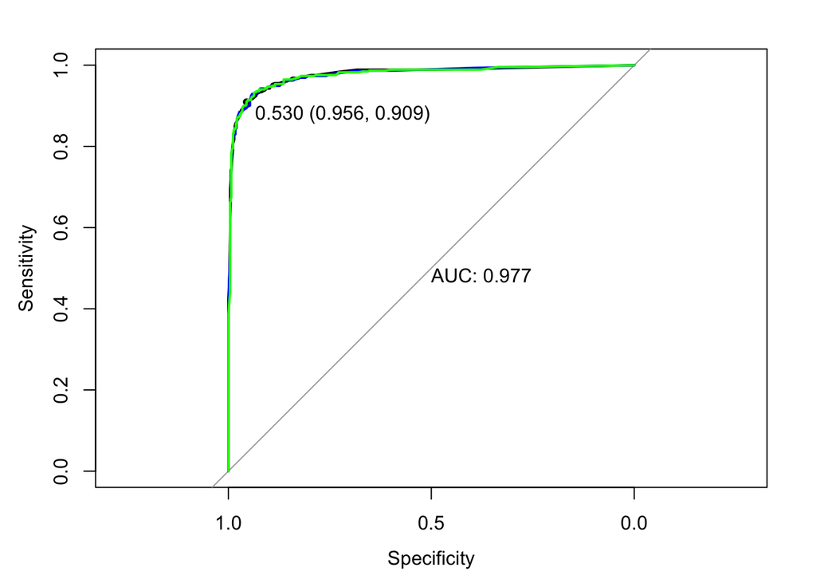

```r
fit_rf_50 = randomForest(y_train ~., data=X_train, ntree=50)
fit_rf_100 = randomForest(y_train ~., data=X_train, ntree=100)
fit_rf_500 = randomForest(y_train ~., data=X_train, ntree=500)

yhat_test_50 = predict(fit_rf_50, newdata=X_test, type="prob")[,2]
yhat_test_100 = predict(fit_rf_100, newdata=X_test, type="prob")[,2]
yhat_test_500 = predict(fit_rf_500, newdata=X_test, type="prob")[,2]

roc50 = roc(test$spam, yhat_test_50)
roc100 = roc(test$spam, yhat_test_100)
roc500 = roc(test$spam, yhat_test_500)
plot(roc50, print.auc = TRUE, auc.polygon = FALSE, auc.polygon.col = "cornflowerblue", print.thres = "best")
lines(roc100, col="blue", lwd=2)
lines(roc500, col="green", lwd=2)
```

```r
auc50 = auc(roc50)
auc100 = auc(roc100)
auc500 = auc(roc500)
```

```r
cat("\nAUC for Random Forest with 50 trees ", auc50)
```

```
AUC for Random Forest with 50 trees  0.9771015
```

```r
cat("\nAUC for Random Forest with 100 trees ", auc100)
```

```
AUC for Random Forest with 100 trees  0.976875
```

```r
cat("\nAUC for Random Forest with 500 trees ", auc500)
```

```
AUC for Random Forest with 500 trees  0.9765805
```

**The ROC curves and also area under the curve (AUC) are very similar for the three random forest models. This could suggest that random forest models can perform well regardless of the number of trees specified. It seems that regardless of the tree specification the fits are capturing the underlying data effectively.**

#### 💪 Problem 2.2

```r
threshold = 0.5 # Predict spam if probability > threshold
yhat_test_100_prob = as.factor(yhat_test_100 > threshold)
levels(yhat_test_100_prob)  = c("not spam", "spam")
confusionMatrix(data = yhat_test_100_prob, test$spam, positive = "spam")
```

```
Confusion Matrix and Statistics

          Reference
Prediction not spam spam
  not spam      660   45
  spam           37  408

               Accuracy : 0.9287
                 95% CI : (0.9123, 0.9429)
    No Information Rate : 0.6061
    P-Value [Acc > NIR] : <2e-16

                  Kappa : 0.8502

 Mcnemar's Test P-Value : 0.4395

            Sensitivity : 0.9007
            Specificity : 0.9469
         Pos Pred Value : 0.9169
         Neg Pred Value : 0.9362
             Prevalence : 0.3939
         Detection Rate : 0.3548
   Detection Prevalence : 0.3870
      Balanced Accuracy : 0.9238

       'Positive' Class : spam
```

```r
X_train_xgb <- as.matrix(X_train)
X_test_xgb <- as.matrix(X_test)
y_train_xgb <- as.integer(y_train) - 1
y_test_xgb <- as.integer(y_test) - 1
```

#### 💪 Problem 2.3

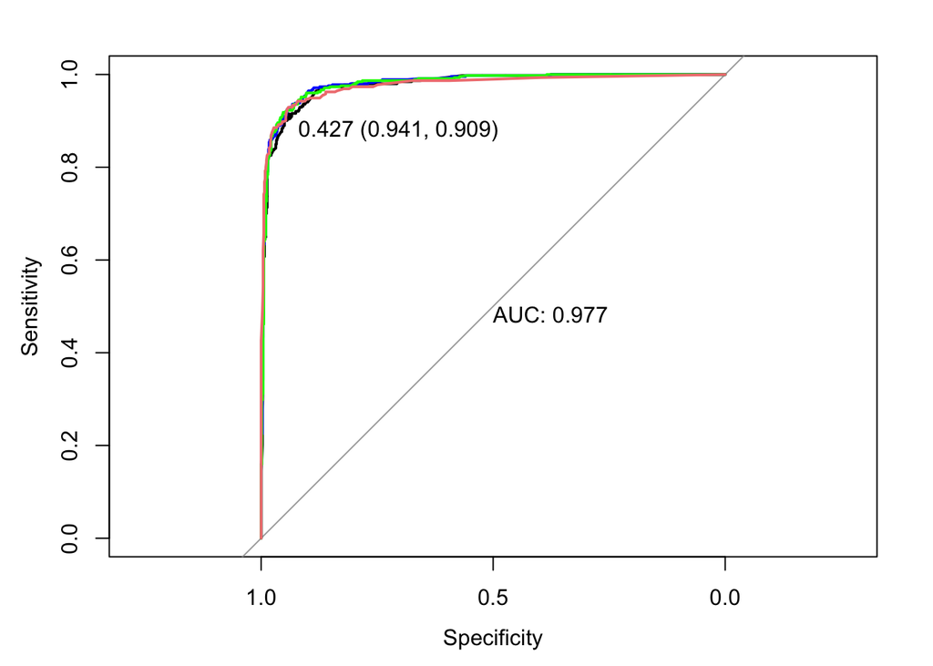

```r
X_train_xgb <- as.matrix(X_train)
X_test_xgb <- as.matrix(X_test)
y_train_xgb <- as.integer(y_train) - 1
y_test_xgb <- as.integer(y_test) - 1

fit_boost_10 = xgboost(data = X_train_xgb, label = y_train_xgb, nrounds = 10, objective = "binary:logistic", verbose = 0)
fit_boost_25 = xgboost(data = X_train_xgb, label = y_train_xgb, nrounds = 25, objective = "binary:logistic", verbose = 0)
fit_boost_50 = xgboost(data = X_train_xgb, label = y_train_xgb, nrounds = 50, objective = "binary:logistic", verbose = 0)

yhat_test_10 = predict(fit_boost_10, newdata = X_test_xgb)
yhat_test_25 = predict(fit_boost_25, newdata = X_test_xgb)
yhat_test_50 = predict(fit_boost_50, newdata = X_test_xgb)

roc_boost_10 = roc(y_test_xgb, yhat_test_10)
roc_boost_25 = roc(y_test_xgb, yhat_test_25)
roc_boost_50 = roc(y_test_xgb, yhat_test_50)
plot(roc_boost_10, print.auc = TRUE, auc.polygon = FALSE, auc.polygon.col = "cornflowerblue", print.thres = "best")
lines(roc_boost_25, col="blue", lwd=2)
lines(roc_boost_50, col="green", lwd=2)
lines(roc100, col="lightcoral", lwd=2)
```

```r
auc_boost_10 = auc(roc_boost_10)
auc_boost_25 = auc(roc_boost_25)
auc_boost_50 = auc(roc_boost_50)
```

```r
cat("\nAUC for xgboost with 10 rounds ", auc_boost_10)
```

```
AUC for xgboost with 10 rounds  0.9772329
```

```r
cat("\nAUC for xgboost with 25 rounds ", auc_boost_25)
```

```
AUC for xgboost with 25 rounds  0.980598
```

```r
cat("\nAUC for xgboost with 50 rounds ", auc_boost_50)
```

```
AUC for xgboost with 50 rounds  0.9799171
```

#### 💪 Problem 2.4

```r
threshold = 0.5 # Predict spam if probability > threshold
yhat_test_25_prob = as.factor(yhat_test_25 > threshold)
levels(yhat_test_25_prob)  = c("not spam", "spam")
confusionMatrix(data = yhat_test_25_prob, test$spam, positive = "spam")
```

```
Confusion Matrix and Statistics

          Reference
Prediction not spam spam
  not spam      658   36
  spam           39  417

               Accuracy : 0.9348
                 95% CI : (0.9189, 0.9484)
    No Information Rate : 0.6061
    P-Value [Acc > NIR] : <2e-16

                  Kappa : 0.8636

 Mcnemar's Test P-Value : 0.8174

            Sensitivity : 0.9205
            Specificity : 0.9440
         Pos Pred Value : 0.9145
         Neg Pred Value : 0.9481
             Prevalence : 0.3939
         Detection Rate : 0.3626
   Detection Prevalence : 0.3965
      Balanced Accuracy : 0.9323

       'Positive' Class : spam
```

## 3. Learning parametric models by gradient based optimisation

```r
rm(list=ls()) # Remove variables
cat("\014") # Clean workspace
```

```r
gen_x <- function(seed=123){
  set.seed(seed)
  return(runif(0, 1, n = 1000))
}
# Test
x <- gen_x()
length(x)
```

```
[1] 1000
```

```r
head(x)
```

```
[1] 0.2875775 0.7883051 0.4089769 0.8830174 0.9404673 0.0455565
```

#### 💪 Problem 3.1

```r
beta_0 = 0.3
beta_1 = 2.5

lambda = exp(beta_0 + beta_1 * x)

y = rpois(1000, lambda)
```

#### 💪 Problem 3.2

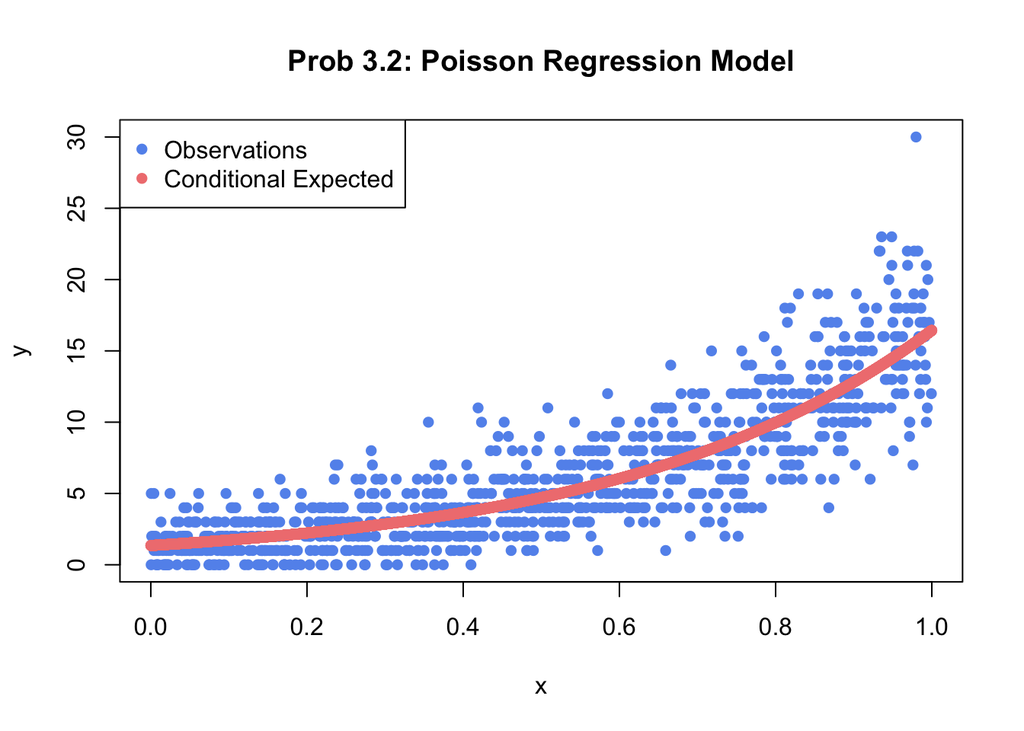

```r
x_grid = seq(0, 1, length.out=10000)

conditional_expected = exp(beta_0 + beta_1 * x_grid)

plot(x, y,  xlab = "x",ylab = "y",
     main = "Prob 3.2: Poisson Regression Model",
     col = "cornflowerblue",
     pch = 16)
points(x_grid, conditional_expected, col = "lightcoral", pch = 16)
legend(x = "topleft", pch = c(16, 16), col = c("cornflowerblue", "lightcoral"), legend=c("Observations", "Conditional Expected"))
```

#### 💪 Problem 3.3

PMF for Poisson Model:

$$p(y|\mu)=\frac{\mu^y\exp(-\mu)}{y!}$$

Where:

$$\mu_i = exp(\beta_0 + \beta_1*x_i)$$

Across observations:

$$\prod_{i=1}^{n} p(Y_i|X_i, \beta) = \prod_{i=1}^{n} \frac{exp(-\mu_i)\mu_i^{Y_i}}{Y_{i}!} = \prod_{i=1}^{n} \frac{exp(-\exp(\beta_0 + \beta_1*x_i))\exp(\beta_0 + \beta_1*x_i)^{Y_i}}{Y_{i}!}$$

Since y’s are independent:

$$p(Y_1,Y_2,…,Y_n|X_1,X_2,….,X_n) = p(Y_1|X_1) * f(Y_2|X_2) * … * p(Y_n|X_n)$$

Taking Logs:

$$\ell(\beta_0, \beta_1)=\log p(y_1,y_2,\dots,y_n|x_1,x_2,\dots,x_n,\beta_0, \beta_1)$$

$$\ell(\beta_0, \beta_1) = \sum_{i=1}^{n} ln(\frac{exp(-\mu_i))\mu_i^{Y_i}}{y_i!}) = \sum_{i=1}^{n} [ln(\exp(-\mu_i)) - ln(y_i!) + ln(\mu_{i}^{y_i})]$$

$$\therefore \ell(\beta_0, \beta_1) = \sum_{i=1}^{n}[-exp(\beta_0 + \beta_1*x_i) - ln(y_i!) + y_i*(\beta_0 + \beta_1*x_i) )]$$

#### 💪 Problem 3.4

To find the gradient, we take the derivative of the below expression with respect to each parameter:

$$\sum_{i=1}^{n}[-exp(\beta_0 + \beta_1*x_i) - ln(y_i!) + y_i*(\beta_0 + \beta_1*x_i) )]$$

For $\partial\beta_0$:

$$\frac{\partial \ln p(y_i|x_i,\beta_0, \beta_1)}{\partial \beta_1^2} = \sum_{i=1}^{n}[y_i - e^{(\beta_0 + \beta_1 * x_i)}]$$

For $\partial\beta_1$:

$$\frac{\partial \ln p(y_i|x_i,\beta_0, \beta_1)}{\partial \beta_1^2} = \sum_{i=1}^{n}[y_i * x_i - x_i * e^{(\beta_0 + \beta_1 * x_i)}] = \sum_{i=1}^{n}x_i * [y_i - e^{(\beta_0 + \beta_1 * x_i)}]$$

#### 💪 Problem 3.5

```r
loss_func = function (y, x, beta_0, beta_1) {
  sum(y * (beta_0 + beta_1 * x) - exp(beta_0 + beta_1 * x) - log(factorial(y)))
}

grads = function (y, x, beta_0, beta_1) {
  dB0 <- sum(y - exp(beta_0 + beta_1 * x))
  dB1 <- sum(x * (y - exp(beta_0 + beta_1 * x)))
  output <- c(dB0, dB1)
  return(output)
}
```

#### 💪 Problem 3.6

```r
cost_func = function(n, log_loss) {
  -(1/n) * log_loss
}

gradient_func = function(n, gradients) {
  -(1/n) * gradients
}

gradient_descent = function (y, x, learning_rate, iterations) {

  beta_0 <- 1.0
  beta_1 <- 1.0
  betas <- c(beta_0, beta_1)
  n <- length(y)

  beta_track <- matrix(0, nrow = n, ncol = length(betas))
  cost_track <- c()

  for(i in 1:iterations){

    loss <- loss_func(y, x, betas[1], betas[2])
    cost <- cost_func(n, loss)
    cost_track[i] <- cost

    gradients <- grads(y, x, betas[1], betas[2])
    update <- gradient_func(n, gradients)

    betas <- betas - learning_rate * update
    beta_track[i,] = betas

  }

  return(
    list(
      Params = betas,
      Beta_hist = beta_track,
      Loss_hist = cost_track))


}

params_0.01 <- gradient_descent(y, x, 0.01, 200)
params_0.1 <- gradient_descent(y, x, 0.1, 200)
params_0.25 <- gradient_descent(y, x, 0.25, 200)

LR_0.01_est <- params_0.01$Params
LR_0.1_est <- params_0.1$Params
LR_0.25_est <- params_0.25$Params

cat("\nParameter Estimates for LR = 0.01: ", LR_0.01_est[1], LR_0.01_est[2])
```

```
Parameter Estimates for LR = 0.01:  0.8201743 1.762188
```

```r
cat("\nParameter Estimates for LR = 0.1: ", LR_0.1_est[1], LR_0.1_est[2])
```

```
Parameter Estimates for LR = 0.1:  0.2924894 2.523089
```

```r
cat("\nParameter Estimates for LR = 0.01: ", LR_0.25_est[1], LR_0.25_est[2])
```

```
Parameter Estimates for LR = 0.01:  -0.1926454 2.088602
```

```r
#plot the beta and loss
```

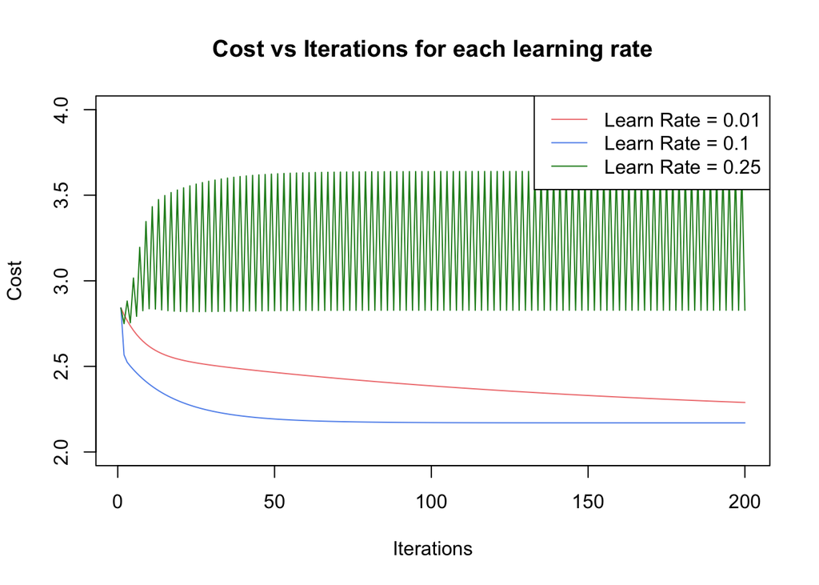

```r
#plot of cost functon for the 3 different learning rates
plot(params_0.01$Loss_hist, type = 'l', col = 'lightcoral', xlab = 'Iterations', ylab = 'Cost', main = 'Cost vs Iterations for each learning rate', ylim = c(2,4))
lines(params_0.1$Loss_hist, col = 'cornflowerblue')
lines(params_0.25$Loss_hist, col = 'forestgreen')
legend("topright", legend = c("Learn Rate = 0.01", "Learn Rate = 0.1", "Learn Rate = 0.25"), col = c('lightcoral', 'cornflowerblue', 'forestgreen'), lty = 1)
```

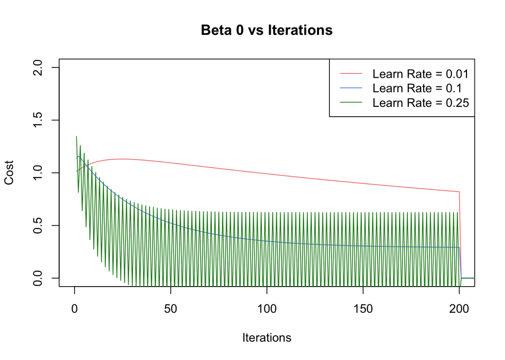

```r
#plot of updates vs the iteration number for the 3 different learning rates - Beta 0
plot(params_0.01$Beta_hist[,1], type = 'l', col = 'lightcoral', xlab = 'Iterations', ylab = 'Cost', main = 'Beta 0 vs Iterations', xlim = (c(0,200)), ylim = c(0,2))
lines(params_0.1$Beta_hist[,1], col = 'cornflowerblue')
lines(params_0.25$Beta_hist[,1], col = 'forestgreen')
legend("topright", legend = c("Learn Rate = 0.01", "Learn Rate = 0.1", "Learn Rate = 0.25"), col = c('lightcoral', 'cornflowerblue', 'forestgreen'), lty = 1)
```

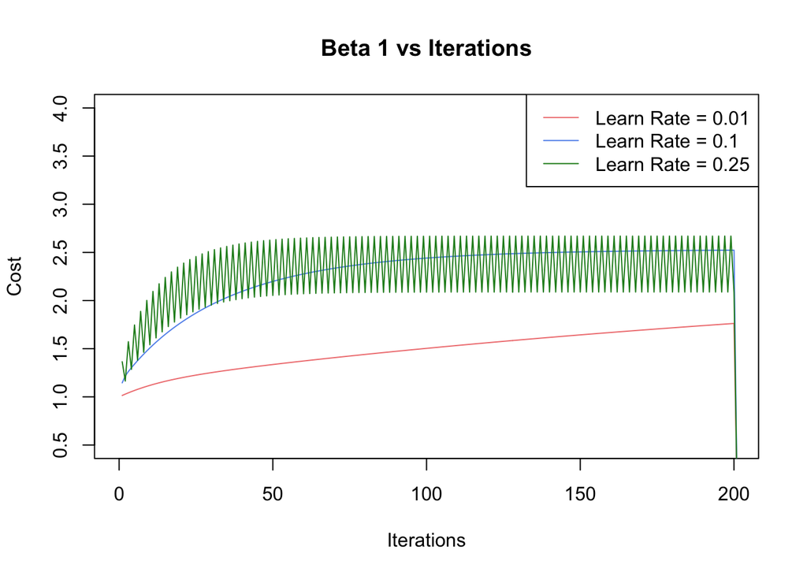

```r
#plot of updates vs the iteration number for the 3 different learning rates - Beta 1
plot(params_0.01$Beta_hist[,2], type = 'l', col = 'lightcoral', xlab = 'Iterations', ylab = 'Cost', main = 'Beta 1 vs Iterations', xlim = (c(0,200)), ylim = c(0.5,4))
lines(params_0.1$Beta_hist[,2], col = 'cornflowerblue')
lines(params_0.25$Beta_hist[,2], col = 'forestgreen')
legend("topright", legend = c("Learn Rate = 0.01", "Learn Rate = 0.1", "Learn Rate = 0.25"), col = c('lightcoral', 'cornflowerblue', 'forestgreen'), lty = 1)
```

**Comments: A high learning rate (0.25) results in an erratic cost curve with sharp oscillations, suggesting larger, potentially overshooting steps in the parameter space. In contrast, lower rates (0.01, 0.1) yield smoother curves, reflecting more stable convergence. While 0.01 provides stability, it never gets close to the true parameter values due to the small step size. The 0.1 rate strikes a balance, offering both speed and stability towards the minima.**

#### 💪 Problem 3.7

```r
stochastic_descent = function (y, x, epochs, batch_size) {

  beta_0 <- 1.0
  beta_1 <- 1.0
  beta <- c(beta_0, beta_1)
  n <- length(y)
  nb <- batch_size
  num_of_batches <- n/nb

  cost_track <- c()

  for(i in 1:epochs){

    sample_idx <- sample(1:length(x))
    x <- x[sample_idx]
    y <- y[sample_idx]
    epoch_loss <- 0

    for(j in 1:num_of_batches){

      loss <- loss_func(y[((j-1)*nb+1) : (j*nb)], x[((j-1)*nb+1) : (j*nb)], beta[1], beta[2])
      cost <- cost_func(nb, loss)
      epoch_loss <- epoch_loss + cost

      gradients <- grads(y[((j-1)*nb+1) : (j*nb)], x[((j-1)*nb+1) : (j*nb)], beta[1], beta[2])
      update <- gradient_func(nb, gradients)

      beta <- beta - (0.5 / (j^0.6)) * update

    }
    cost_track[i] <- epoch_loss

  }

  return(list(beta = beta, Cost_hist = cost_track))

}

sgd_10 <- stochastic_descent(y, x, 20, 10)
sgd_50 <- stochastic_descent(y, x, 20, 50)
sgd_100 <- stochastic_descent(y, x, 20, 100)

BS_10_est <- sgd_10$beta
BS_50_est <- sgd_50$beta
BS_100_est <- sgd_100$beta

cat("\nParameter Estimates for Batch Size = 10: ", BS_10_est[1], BS_10_est[2])
```

```
Parameter Estimates for Batch Size = 10:  0.2313283 2.408998
```

```r
cat("\nParameter Estimates for Batch Size = 50: ", BS_50_est[1], BS_50_est[2])
```

```
Parameter Estimates for Batch Size = 50:  0.2596121 2.507523
```

```r
cat("\nParameter Estimates for Batch Size = 100: ", BS_100_est[1], BS_100_est[2])
```

```
Parameter Estimates for Batch Size = 100:  0.2860847 2.538431
```

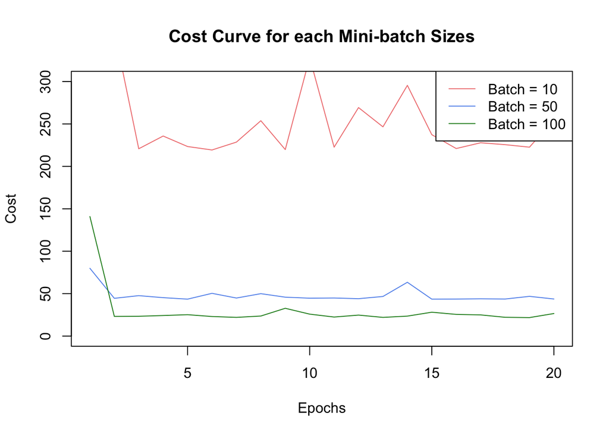

```r
plot(sgd_10$Cost_hist, type = 'l', col = 'lightcoral', xlab = 'Epochs', ylab = 'Cost', main = 'Cost Curve for each Mini-batch Sizes', ylim = c(0, 300))
lines(sgd_50$Cost_hist, col = 'cornflowerblue')
lines(sgd_100$Cost_hist, col = 'forestgreen')
legend("topright", legend = c("Batch = 10", "Batch = 50", "Batch = 100"), col = c('lightcoral', 'cornflowerblue', 'forestgreen'), lty = 1)
```

**Comments: based on the above plot the a batch size of 100 appears to be the best. The reason being is that it has the cost function is the lowest when using a batch size of 100 at epoch 20, and that the final parameters calculated using a batch size of 100 are closer to the true parameter values when compared to using a batch size of 10 and 50.**

## 4. Learning parametric models by second order optimisation

#### 💪 Problem 4.1

**Tip**

Because of the (conditional) independence assumption
$$\nabla\nabla^\top \ell(\beta_0, \beta_1)=\sum_{i=1}^n \nabla\nabla^\top \log p(y_i|x_i,\beta_0, \beta_1),$$
and note that

$$\nabla\nabla^\top \log p(y_i|x_i,\beta_0, \beta_1) = \begin{bmatrix}
\frac{\partial^2}{\partial\beta_0^2}\log p(y_i|x_i,\beta_0, \beta_1) & \frac{\partial^2}{\partial\beta_0\partial\beta_1}\log p(y_i|x_i,\beta_0, \beta_1) \\
\frac{\partial^2}{\partial\beta_1\partial\beta_0}\log p(y_i|x_i,\beta_0, \beta_1) & \frac{\partial^2}{\partial\beta_1^2}\log p(y_i|x_i,\beta_0, \beta_1)
\end{bmatrix}.$$

To derive the Hessian matrix we can use our results from 3.4 to find the second order partial derivatives with respect to each parameter:

For $\partial\beta_0^2$ :

$$\frac{\partial \ln p(y_i|x_i,\beta_0, \beta_1)}{\partial \beta_1^2} = \sum_{i=1}^{n}[- e^{(\beta_0 + \beta_1 * x_i)}]$$

For $\partial\beta_1^2$:

$$\frac{\partial \ln p(y_i|x_i,\beta_0, \beta_1)}{\partial \beta_1^2} = \sum_{i=1}^{n}[-x_i^2 * e^{(\beta_0 + \beta_1 * x_i)}]$$

For $\partial\beta_0\partial\beta_1 = \partial\beta_1\partial\beta_0$:

$$\frac{\partial \ln p(y_i|x_i,\beta_0, \beta_1)}{\partial \beta_1^2} = \frac{\partial \ln p(y_i|x_i,\beta_0, \beta_1)}{\partial \beta_1^2} = \sum_{i=1}^{n}[-x_i * e^{(\beta_0 + \beta_1 * x_i)}]$$

#### 💪 Problem 4.2

```r
# Note: Fill in the NAs!
Hess_log_dens_single_obs <- function(beta, y_i, X_i) {
  phi11 <- -exp(beta[1] + beta[2] * X_i)
  phi12 <- -exp(beta[1] + beta[2] * X_i) * X_i
  phi21 <- phi12
  phi22 <-  -exp(beta[1] + beta[2] * X_i) * X_i^2
  return(matrix(c(phi11, phi21, phi12, phi22), nrow = 2, ncol = 2))
}

Hess_log_like <- function(beta, y, X) {
  n <- length(y)
  sum_Hess_log_like <- matrix(rep(0, 4), nrow = 2, ncol = 2)
  for(i in 1:n) {
    sum_Hess_log_like <- sum_Hess_log_like + Hess_log_dens_single_obs(beta, y[i], X[i ])
  }
  return(sum_Hess_log_like)
}
```

#### 💪 Problem 4.3

```r
newton_descent = function (y, x, iterations, trust_region) {

  beta_0 <- 0.0
  beta_1 <- 0.0
  beta <- c(beta_0, beta_1)
  n <- length(y)


  cost_track <- c()

  for(i in 1:iterations){

    loss <- loss_func(y, x, beta[1], beta[2])
    cost <- cost_func(n, loss)
    cost_track[i] <- cost

    gradients <- grads(y, x, beta[1], beta[2])
    hessian <- -(1/n) * Hess_log_like(beta, y, x)
    v <- solve(hessian) %*% gradient_func(n, gradients)
    learning_rate <- (trust_region / max(norm(v, type="2"), trust_region))

    beta <- beta - learning_rate * v


  }

  return(
    list(
      Params = beta,
      Cost_hist = cost_track))


}

test_newton <- newton_descent(y, x, 200, 1)

newton_est <- test_newton$Params

cat("\nParameter estimates using Newtons Method: ", newton_est[1], newton_est[2])
```

```
Parameter estimates using Newtons Method:  0.2875777 2.529934
```

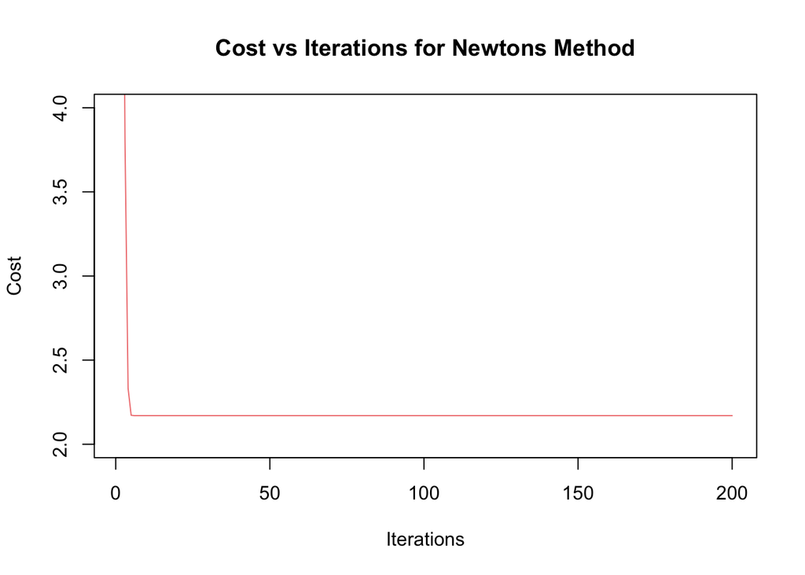

```r
plot(test_newton$Cost_hist, type = 'l', col = 'lightcoral', xlab = 'Iterations', ylab = 'Cost', main = 'Cost vs Iterations for Newtons Method', ylim = c(2,4))
```

**When comparing the rate of convergence between Newtons Method and SGD we can see that Newtons Method converges to the minimum much faster that SGD. By incorporating information from the Hessian of the cost function Newtons Method is able to converge quadratically to the minimum in just a few steps, SGD on the other hand requires multiple run-throughs of the training data set to achieve the same result**

## 5. Learning parametric models using the optim function

```r
log_dens_Poisson <- function(beta, y, X) {
  # log-density for each y_i, X_i
  return(dpois(y, lambda = exp(X%*%beta),log = TRUE))
}

log_like_Poisson <- function(beta, y, X) {
  # log-likelihood (for all observations)
  return(sum(log_dens_Poisson(beta, y, X)))
}
```

#### 💪 Problem 5.1

```r
cost_function = function(beta, y, X){

    return(-(1/n) * log_like_Poisson(beta, y, X))

}
```

#### 💪 Problem 5.2

```r
beta_start = c(0,2)
n <- 1000

X = as.matrix(cbind(1, x), ncol = 2)

obj = optim(par = beta_start, fn=cost_function, y=y, X=X, method = "L-BFGS-B")

obj$par #these are the true parameter values
```

```
[1] 0.2875769 2.5299348
```

#### 💪 Problem 5.3

```r
load(file = "eBay_coins.RData")

ebay_response = as.matrix(eBay_coins$nBids) #this is y
ebay_features = as.matrix(select(eBay_coins, -nBids))#this is X
beta_start = rep(1, ncol(ebay_features))

betas = optim(par = beta_start, fn=cost_function, y=ebay_response,X=ebay_features)$par

#PRINT OUT NAME AND OPTIMISED VALUE

cat("\nConst: ", betas[1])
```

```
Const:  0.6863134
```

```r
cat("\nPowerSeller: ", betas[2])
```

```
PowerSeller:  0.6383085
```

```r
cat("\nVerifyID: ", betas[3])
```

```
VerifyID:  -0.5009561
```

```r
cat("\nSealed: ", betas[4])
```

```
Sealed:  0.04158468
```

```r
cat("\nMinBlem: ", betas[5])
```

```
MinBlem:  0.668109
```

```r
cat("\nMajBlem: ", betas[6])
```

```
MajBlem:  -0.1680877
```

```r
cat("\nLargNeg: ", betas[7])
```

```
LargNeg:  0.444599
```

```r
cat("\nLogBook: ", betas[8])
```

```
LogBook:  0.08093386
```

```r
cat("\nMinBidShare: ", betas[9])
```

```
MinBidShare:  -1.624861
```

#### 💪 Problem 5.4

```r
new_data = c(1, 1, 1, 1, 0, 0 ,0 ,1, 0.5)

point_estimate = exp(t(new_data) %*% betas)

cat("\nThe point estimate is ", point_estimate)
```

```
The point estimate is  1.143111
```